# Factors Associated with Anxiety Levels

Exploring how lifestyle habits are associated with anxiety levels

A regression case study examining the relationship between lifestyle habits and anxiety levels.

Author

Nada Amer, Hiram Lopez Mendoza, Lucero Otero

Published

November 9, 2026

## The question

> Our research question is: How are a person’s lifestyle behaviors related to the intensity of their social anxiety? Our intended audience includes clinicians, researchers interested in social anxiety, and individuals experiencing social anxiety. Finding and understanding the association between daily lifestyle behaviors and social anxiety levels can be helpful for understanding how these factors are related. Our findings could also support current and future experimental studies that seek to investigate causal relationships.

## What the baseline shows

> We fitted a multiple linear regression model to examine the relationship between social anxiety levels and five lifestyle predictors: sleep hours, physical activity, caffeine intake, alcohol consumption, and diet quality.

```r
library(tidyverse)
library(car)

anxiety_data <- read_csv("anxiety.csv")
summary(anxiety_data)
```

```
      Age           Gender           Occupation         Sleep Hours
 Min.   :18.00   Length:11000       Length:11000       Min.   : 2.300
 1st Qu.:29.00   Class :character   Class :character   1st Qu.: 5.900
 Median :40.00   Mode  :character   Mode  :character   Median : 6.700
 Mean   :40.24                                         Mean   : 6.651
 3rd Qu.:51.00                                         3rd Qu.: 7.500
 Max.   :64.00                                         Max.   :11.300
 Physical Activity (hrs/week) Caffeine Intake (mg/day)
 Min.   : 0.000               Min.   :  0.0
 1st Qu.: 1.500               1st Qu.:172.0
 Median : 2.800               Median :273.0
 Mean   : 2.942               Mean   :286.1
 3rd Qu.: 4.200               3rd Qu.:382.0
 Max.   :10.100               Max.   :599.0
 Alcohol Consumption (drinks/week)   Smoking          Family History of Anxiety
 Min.   : 0.000                    Length:11000       Length:11000
 1st Qu.: 5.000                    Class :character   Class :character
 Median :10.000                    Mode  :character   Mode  :character
 Mean   : 9.702
 3rd Qu.:15.000
 Max.   :19.000
 Stress Level (1-10) Heart Rate (bpm) Breathing Rate (breaths/min)
 Min.   : 1.000      Min.   : 60.00   Min.   :12.00
 1st Qu.: 3.000      1st Qu.: 76.00   1st Qu.:17.00
 Median : 6.000      Median : 92.00   Median :21.00
 Mean   : 5.856      Mean   : 90.92   Mean   :20.96
 3rd Qu.: 8.000      3rd Qu.:106.00   3rd Qu.:25.00
 Max.   :10.000      Max.   :119.00   Max.   :29.00
 Sweating Level (1-5)  Dizziness          Medication
 Min.   :1.000        Length:11000       Length:11000
 1st Qu.:2.000        Class :character   Class :character
 Median :3.000        Mode  :character   Mode  :character
 Mean   :3.081
 3rd Qu.:4.000
 Max.   :5.000
 Therapy Sessions (per month) Recent Major Life Event Diet Quality (1-10)
 Min.   : 0.000               Length:11000            Min.   : 1.000
 1st Qu.: 1.000               Class :character        1st Qu.: 3.000
 Median : 2.000               Mode  :character        Median : 5.000
 Mean   : 2.428                                       Mean   : 5.182
 3rd Qu.: 4.000                                       3rd Qu.: 8.000
 Max.   :12.000                                       Max.   :10.000
 Anxiety Level (1-10)
 Min.   : 1.000
 1st Qu.: 2.000
 Median : 4.000
 Mean   : 3.929
 3rd Qu.: 5.000
 Max.   :10.000
```

```r
anxiety_data <- anxiety_data |>
  rename(
    anxiety_lvl = `Anxiety Level (1-10)`,
    sleep_hrs = `Sleep Hours`,
    physical_activity = `Physical Activity (hrs/week)`,
    caffeine_intake = `Caffeine Intake (mg/day)`,
    alcohol_consumption = `Alcohol Consumption (drinks/week)`,
    diet_quality = `Diet Quality (1-10)`
  )

anxiety_fit <- lm(
  anxiety_lvl ~ sleep_hrs + physical_activity +
    caffeine_intake + alcohol_consumption + diet_quality,
  data = anxiety_data
)

summary(anxiety_fit)
```

```
Call:
lm(formula = anxiety_lvl ~ sleep_hrs + physical_activity + caffeine_intake +
    alcohol_consumption + diet_quality, data = anxiety_data)

Residuals:
    Min      1Q  Median      3Q     Max
-5.8051 -1.2399 -0.0395  1.2025  5.2951

Coefficients:
                      Estimate Std. Error t value Pr(>|t|)
(Intercept)          8.2230631  0.1119209  73.472  < 2e-16 ***
sleep_hrs           -0.6874510  0.0139434 -49.303  < 2e-16 ***
physical_activity   -0.1552726  0.0091438 -16.981  < 2e-16 ***
caffeine_intake      0.0035042  0.0001162  30.158  < 2e-16 ***
alcohol_consumption  0.0211791  0.0028861   7.338 2.31e-13 ***
diet_quality        -0.0912460  0.0057434 -15.887  < 2e-16 ***
---
Signif. codes:  0 '***' 0.001 '**' 0.01 '*' 0.05 '.' 0.1 ' ' 1

Residual standard error: 1.717 on 10994 degrees of freedom
Multiple R-squared:  0.3458,    Adjusted R-squared:  0.3455
F-statistic:  1162 on 5 and 10994 DF,  p-value: < 2.2e-16
```

> Holding physical activity, caffeine intake, alcohol consumption, and dietary quality constant, an increase in one hour of sleep is associated with a predicted decrease of about 0.6875 points in social anxiety level, on average.

> We are 95% confident that, holding the other predictors constant, each additional hour of sleep is associated with a decrease of between 0.660 and 0.715 points in the mean social anxiety level.

> One possible limitation is multicollinearity, because some lifestyle predictors might be related. For example, caffeine intake could be related to the number of hours slept, and alcohol consumption could also be related to dietary quality. This might make our standard errors bigger and make it harder to interpret each predictor’s individual relationship with anxiety levels.

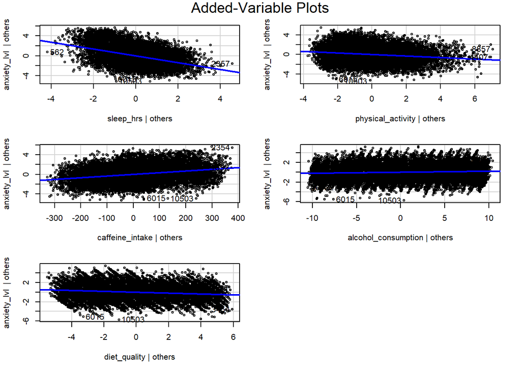

```r
avPlots(anxiety_fit)
```

> The added-variable plots show each predictor’s relationship with social anxiety levels after accounting for the other predictors in our regression model. Sleep hours appear to have the strongest negative relationship with social anxiety, while caffeine intake shows a positive relationship. Physical activity, alcohol consumption, and diet quality show weaker relationships.